# Upgrading Towers

With the current mechanics, players have limited strategies to try out and we have little space for designing new levels. The main problem is that towers have fixed properties. Fixed fire range, fixed damage, fixed fire rate, and fixed selling price.

It’s time to add a layer of complexity to our game. Players should be able to invest resources in a tower to make it better. This allow towers in the same class to perform different roles and even specialize. Yes, we are talking about *upgrades*!

In this lesson you’ll learn to:

- Create upgrades that change weapon’s properties
- Dynamically list upgrades based on selected towers
- Hook interface to selected tower
- Design an interface panel that always fit in the screen

Before we get started, let’s understand how each component of our upgrade system relate to each other.

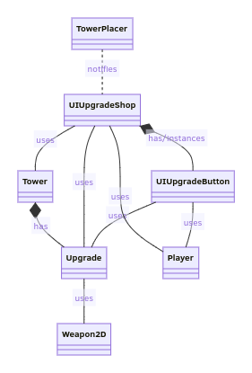

Upgrades are for *Weapon2Ds*. Each tower will have its own set of upgrades based on its game role. To allow players to decide which tower to upgrade, we create a *UIUpgradeShop* to read the list of upgrades from a tower and create *UIUpgradeButtons* based on them. Players buy upgrades using these buttons.

Let’s do it then!

## Creating upgrades for weapons

Create a new script and save it as `res://Objects/Towers/Upgrades/Upgrade.gd`.

The idea of our *Upgrade* class is to be a minimal interface that we can use to create more specific upgrades. It uses an `applied` signal that passes how much it costs to apply the upgrade.

We create a variable for the upgrade button `display_name` and `description`. We can use a MULTILINE export tip to easily write longer descriptions in the *Inspector*.

Each upgrade should store its own `cost` because as players apply the upgrade, they should increase their cost for that tower instance. We create a `cost_multiplier` variable and use it every time players apply an upgrade. These are all exported variables, so we can set different values directly from the *Inspector* for each upgrade.

We create a general variable called `value` which, for instance, is how much a weapon’s fire range should increase on each application of the upgrade. This should be a float value so we have the option to choose if we want to use percentages or absolute values.

Now, the most important property of an upgrade is to which weapon it should apply its bonuses. Towers will inject their weapon into their upgrades.

```
class_name Upgrade
extends Node

signal applied(cost)

export var display_name := "Upgrade name"
export(String, MULTILINE) var description := "Upgrade description"
export var cost := 100
export var cost_multiplier := 1.2
export var value := 100.0

var weapon: Weapon2D
```

Now, let’s create a virtual method that we can override in inherited classes. It tells the effects of our upgrade. Let’s call this virtual method `_apply()` and leave it blank using the `pass` keyword.

To allow other classes to tell when the upgrade should apply, for instance when players click on a button, we create a public method called `apply()`. Inside this method, we run the virtual `_apply()` method. Also, after applying its effect, the upgrade should increase in price and notify that it just applied using its `applied` signal.

### Code so far

So this is how the base *Upgrade* class should look like at the moment.

`Upgrade.gd`

```
class_name Upgrade
extends Node

signal applied(cost)

export var display_name := "Upgrade name"
export(String, MULTILINE) var description := "Upgrade description"
export var cost := 100
export var cost_multiplier := 1.2
export var value := 100.0

var weapon: Weapon2D


func apply() -> void:
    _apply()
    cost *= cost_multiplier
    emit_signal("applied", cost)


# Virtual method, override in children according to upgrade effect
func _apply() -> void:
    pass
```

This system looks simple, but it’s very powerful. Let’s create a concrete upgrade so you can see how to use this class.

## Creating a fire range upgrade

Create a new script that inherits our *Upgrade* and save it as `res://Objects/Towers/Upgrades/FireRangeUpgrade.gd`. Let’s override the `_apply()` virtual method.

In this method, we increase the current `weapon.fire_range` by an absolute value based on the upgrade `value`. In this specific case, we want to show the weapon’s range after we apply the upgrade to provide visual feedback to players.

This is how our *FireRangeUpgrade* code should look like:

`FireRangeUpgrade.gd`

```
extends Upgrade


func _apply() -> void:
    weapon.fire_range += value
    weapon.show_range()
```

Beautiful, isn’t it? Let’s move on to the implementation of the upgrades.

## Adding upgrades to towers

In our game, towers are the ones that store a list with their upgrades. Open our `res://Objects/Towers/Tower.tscn` scene to see how this works.

We create a container node that accesses all the upgrades at once. Add a new *Node* as a child of the *Tower* and name it *Upgrades*. Every child of this node should be an *Upgrade*.

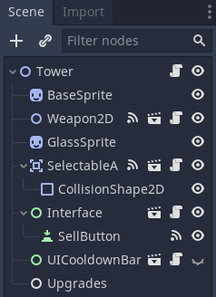

In the *Tower*’s script, let’s add some features to reflect this new system. First, we create a reference for the *Upgrades* node. In the `_ready()` callback, we run through upgrades and inject the tower’s into them.

We’ve decided it would be interesting if the tower’s `cost` increases as players upgrade them. This makes so that when they sell the tower, they receive part of their whole investment, including investing on upgrades. We connect every `upgrade` `applied` signal to a callback in the tower. Then in this callback, we increase the tower’s `cost` by the upgrade’s `cost`.

```
onready var _upgrades := $Upgrades


func _ready() -> void:
    _weapon.show_range()
    for upgrade in _upgrades.get_children():
        upgrade.weapon = _weapon
        upgrade.connect("applied", self, "_on_Upgrade_applied")

func _on_Upgrade_applied(upgrade_cost: int) -> void:
    cost += upgrade_cost
```

[figure not shown]

```
func get_upgrades() -> Array:
    return _upgrades.get_children()
```

This will be super useful when the *UIUpgradeShop* needs to list a tower’s upgrades.

That’s all it takes to wire towers to their upgrades. But now we have a small issue. Towers should have different upgrades based on their unique features. But if we add upgrades in this base *Tower*, they’ll also appear in the *BombTower*. This can be useful if you want some upgrades to appear in all towers. But the *FireRangeUpgrade* shouldn’t be available for the *BombTower*.

Let’s create a new inherited scene based on this base *Tower* scene. We can save it as `res://Objects/Towers/RifleTower.tscn`. In this new scene, add a new *Node* as child of the *Upgrades* node. Name it *FireRangeUpgrade* and drag and drop the `res://Objects/Towers/Upgrades/FireRangeUpgrade.gd` file on this new node to attach this script on it.

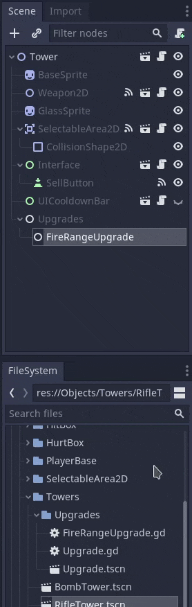

With that, we have a concrete upgrade to play with! Using the *Inspector*, let’s set its properties according to our design. Starting with the *Display Name*, we can set it to `Fire Range`. Then, for the *Description*, let’s write something like `Increases the tower's reach.`.

Other properties depend a lot on design and balance, which is up to you.

Since the *RifleTower* is essentially a base *Tower* with a *FireRangeUpgrade*, the base *Tower* isn’t relevant for our game anymore. So we need to add the *RifleTower* to our *UITowerShop* instead of the previous base *Tower*.

Open the `res://UI/UITowerShop/UITowerShop.tscn` scene. Drag the `res://Objects/Towers/RifleTower.tscn` file to the first *UITowerPurchaseButton > Tower Scene* property and we are good.